# Predição da perda de matéria seca em grãos de soja usando algoritmos de aprendizado de máquina

Autores

Felipe Guzzo e [Juliana Soares Zeymer](https://www.linkedin.com/in/juliana-soares-zeymer-365a31205/)

Data de Publicação

23-03-2023

# Introdução

A soja é uma das culturas mais importantes do agronegócio mundial, sendo utilizada tanto na alimentação animal como humana. No que diz respeito às operações pós-colheita dos grãos de soja, um dos grandes desafios enfrentados pelos armazenistas é a perda de matéria seca dos grãos ao longo do tempo, conhecido popularmente por quebra técnica. Tal perda está associada à respiração da massa de grãos e dos fungos e insetos associados.

Diversos fatores contribuem para o aumento da taxa respiratória, tais como: teor de umidade, temperatura, umidade relativa intergranular, crescimento de insetos e fungos. Uma vez que o ambiente de armazenagem é dinâmico e tais fatores se correlacionam, a quantificação da perda de matéria seca acumulativa sofrida pelos grãos se torna complexa.

Uma das soluções propostas para tal problema é a utilização de modelos preditivos de aprendizado de máquina. Este documento tem como objetivo demonstrar os passos para se obter estimativas da perda de matéria seca de grãos de soja armazenados utilizando o framework tidymodels, contribuindo como uma ferramenta de análise de riscos e tomada de decisão na armazenagem de grãos.

Para melhor entendimento do leitor, os passos apresentados a seguir foram simplificados e muitos detalhes técnicos ficarão implícitos na análise. Maiores detalhes podem ser visto em Kuhn e Silge (2022).

# Pacotes Necessários

```r
# manipulação e visualização dos dados
library(tidyverse)

# necessário para treinar o modelo cubist
library(rules)

# treinamento dos modelos
library(tidymodels)

tidymodels_prefer()
```

# Análise Exploratória

O banco de dados consiste em 2625 observações da perda de matéria seca (dml) em grãos de soja armazenados em diferentes temperaturas (temperature) e teores de umidade (bu) ao longo de aproximadamente 20 dias (time). Os detalhes pertinentes a coleta dos dados experimentais estão disponíveis em Zeymer et al. (2021) e Zeymer et al. (2023).

```r
glimpse(data)
```

```
Rows: 2,625
Columns: 4
$ dml         <dbl> 0.000000000, 0.002717478, 0.003289578, 0.003289578, 0.0032…
$ time        <dbl> 0.0000, 0.8181, 0.8889, 0.9618, 0.9660, 1.0500, 1.1292, 1.…
$ temperature <dbl> 25, 25, 25, 25, 25, 25, 25, 25, 25, 25, 25, 25, 25, 25, 25…
$ bu          <dbl> 12, 12, 12, 12, 12, 12, 12, 12, 12, 12, 12, 12, 12, 12, 12…
```

Antes de realizar a modelagem dos dados, sempre que possível, é interessante visualizar os dados utilizando gráficos. Como as variáveis tempo e perda de matéria seca são contínuas, um gráfico de dispersão vai produzir o resumo visual dos dados.

```r
# função para legendar os valores de temperatura
temperature_labeller <- function(string) {
    paste("Temperatura", string, "ºC")
}
```

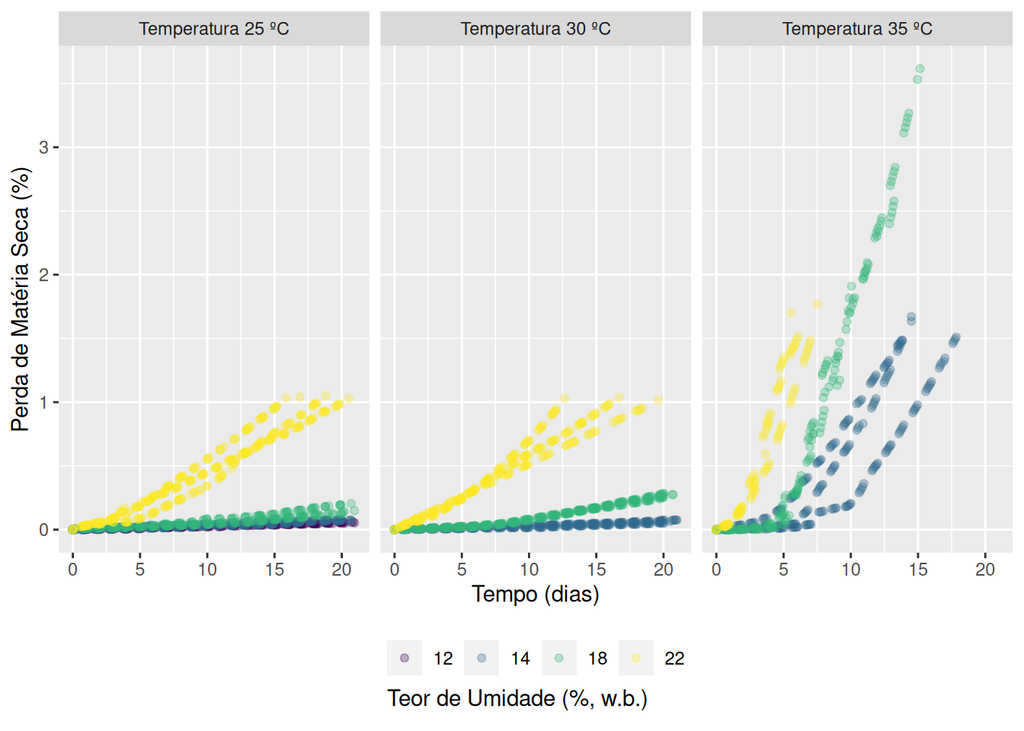

Figura 1: Perda de matéria seca ao longo do tempo para grãos de soja armazenados em diferentes temperaturas (ºC) e teores de umidade (%, w.b)

```r
data |>
    ggplot(
        aes(
            time, dml,
            colour = as_factor(bu)
        )
    ) +
    geom_point(alpha = 0.3) +
    facet_wrap(
        vars(temperature),
        labeller = labeller(
            temperature = temperature_labeller
        )
    ) +
    scale_colour_viridis_d() +
    labs(
        x = "Tempo (dias)",
        y = "Perda de Matéria Seca (%)"
    ) +
    theme(legend.position = "bottom") +
    guides(
        colour = guide_legend(
            title = "Teor de Umidade (%, w.b.)",
            title.position = "bottom"
        )
    )
```

A Figura 1 mostra que a relação entre a temperatura e o teor de umidade são diretamente proporcionais à perda de matéria seca. A medida que a temperatura aumenta, ocorre uma maior perda de matéria seca. O mesmo se aplica para o aumento do teor de umidade. A princípio, parece ser um problema simples de ser resolvido utilizando modelos lineares, devido a relação aparentemente simples entre as variáveis. Porém, como será demostrado no decorrer da análise, um modelo linear pode conter várias interações entre as variáveis explicativas tornando o modelo mais complexo. Os modelos preditivos obtidos nesta análise tem o potencial de se tornar ferramentas de tomada de decisão e de análise de risco de baixo custo.

# Partição dos Dados

Para criar modelos com pouco viés e representativos do fenômeno estudado, é necessário separar os dados em dois conjuntos, treino e teste. No conjunto de treino os modelos são treinados, e no conjunto de teste a performance dos modelos é avaliada. O tamanho das partições ou conjuntos é geralmente escolhida levando em consideração o tamanho do banco de dados disponíveis. Essa escolha pode variar muito de analista para analista, portanto é subjetiva.

Além disso, alguns modelos possuem hiper-parâmetros que precisam ser estimados. Para estimar esses parâmetros, geralmente se utiliza técnicas de re-amostragem como, por exemplo, a validação cruzada. Para essa análise, será utiliza a validação cruzada 10-fold. A técnica consiste em sub-dividir o banco de dados de treino em 10 partes. Em cada partição uma combinação de hiper-parâmetros é treinada e avaliada em relação a alguma métrica.

```r
# partição dos dados 90/10
data_split <- initial_split(data, prop = 0.9)

# dados de treino
data_train <- training(data_split)

# 10-fold
cv_folds <- vfold_cv(data_train, v = 10)
```

# Treinamento dos Modelos

```r
# modelo linear sem hiper-parâmetros
lin_spec <- linear_reg() |>
    set_engine("lm") |>
    set_mode("regression")
```

Para a utilização de modelos lineares, não é necessário estimar hiper-parâmetros. Assim, basta ajustar o modelo nos dados de treino e verificar seu desempenho nos dados de teste.

```r
lin_results <- lin_spec |>
    last_fit(dml ~ ., data_split) |>
    collect_predictions()
```

Um gráfico de dispersão entre os valores observados e preditos é um bom indicador de desempenho. Um modelo ideal teria a maioria dos valores distribuídos com alguma dispersão sobre uma linha 1:1.

```r
# função para plotar os valores observados vs preditos
plot_obs_pred <- function(data) {
    data |>
        ggplot(aes(.pred, dml)) +
        geom_point(alpha = 0.3) +
        geom_abline() +
        coord_obs_pred() +
        labs(
            x = "Perda de Matéria Seca Predita (%)",
            y = "Perda de Matéria Seca Observada (%)"
        )
}
```

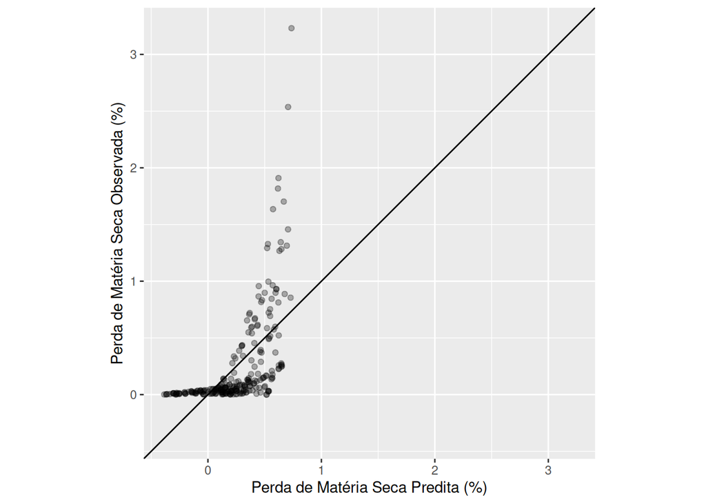

Figura 2: Valores observados vs preditos para o modelo linear

```r
plot_obs_pred(lin_results)
```

A Figura 2 mostra baixo desempenho para o modelo linear. Uma das maneiras de melhorar este parâmetro seria introduzindo interações entre as variáveis explicativas do modelo.

```r
# modelo linear com interações de primeiro grau

inter_recipe <- recipe(dml ~ ., data = data_train) |>
    step_interact(~ all_predictors():all_predictors())

lin_inter_results <- workflow() |>
    add_model(lin_spec) |>
    add_recipe(inter_recipe) |>
    last_fit(data_split) |>
    collect_predictions()
```

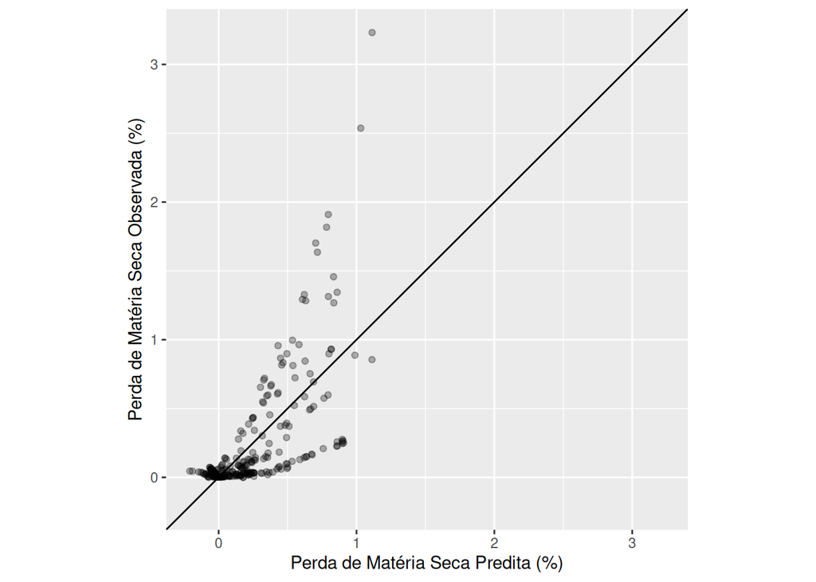

Figura 3: Valores observados vs preditos para o modelo linear com interações

```r
plot_obs_pred(lin_inter_results)
```

Observando a Figura 3 nota-se uma melhora no desempenho do modelo. É possível continuar adicionando interações ao modelo, como as interações de segundo grau. Embora seja possível, não parece ser a estratégia mais viável no momento, visto que demandaria muito tempo e trabalho explorar todas as interações possíveis. Além disso, a verdadeira relação entre as variáveis preditoras não parece ser linear.

Uma estratégia mais eficiente seria utilizar modelos mais flexíveis como random forest, vector support machines e neural networks. Uma vez que esses modelos possuem hiper-parâmetros, se faz necessário estimá-los utilizando validação cruzada. Para estimar ou tunar os hiper-parâmetros desses modelos é necessário marcá-los com a sentença `tune()`.

```r
svm_r_spec <- svm_rbf(cost = tune(), rbf_sigma = tune()) |>
    set_engine("kernlab") |>
    set_mode("regression")

svm_p_spec <- svm_poly(cost = tune(), degree = tune()) |>
    set_engine("kernlab") |>
    set_mode("regression")

rf_spec <- rand_forest(mtry = tune(), min_n = tune(), trees = 1000) |>
    set_engine("ranger") |>
    set_mode("regression")

cubist_spec <- cubist_rules(committees = tune(), neighbors = tune()) |>
    set_engine("Cubist") |>
    set_mode("regression")

nnet_spec <- mlp(hidden_units = tune(), penalty = tune(), epochs = tune()) |>
    set_engine("nnet") |>
    set_mode("regression")
```

Notoriamente, para os modelos baseados em support vector machines e neural networks é recomendado realizar a normalização dos preditores. Dessa vez, todos os modelos serão treinados em uma única etapa. Para essa finalidade existe a função `workflow_set()` para criar um conjunto de dados com todos os modelos a serem treinados, e também a função `workflow_map()` para treinar os modelos no banco de dados de treino.

```r
# para os modelos de support vector machine e neural network
# é recomendado normalizar os preditores
norm_wflow <- workflow_set(
    preproc = list(
        normalized = recipe(dml ~ ., data) |>
            # normalização dos preditores
            step_normalize(all_predictors())
    ),
    models = list(
        svm_radial = svm_r_spec,
        svm_poly = svm_p_spec,
        neural_net = nnet_spec
    )
)

# para os modelos random forest e cubist
# não é necessário realizar a normalização dos preditores
raw_wflow <- workflow_set(
    preproc = list(
        raw = workflow_variables(
            outcomes = dml,
            predictors = everything()
        )
    ),
    models = list(
        rf = rf_spec,
        cubist = cubist_spec
    )
)

all_wflows <- norm_wflow |>
    bind_rows(raw_wflow) |>
    mutate(
        wflow_id =
            gsub(
                "(normalized_)|(raw_)", "", wflow_id
            )
    )

all_wflows
```

```
# A workflow set/tibble: 5 × 4
  wflow_id   info             option    result
  <chr>      <list>           <list>    <list>
1 svm_radial <tibble [1 × 4]> <opts[0]> <list [0]>
2 svm_poly   <tibble [1 × 4]> <opts[0]> <list [0]>
3 neural_net <tibble [1 × 4]> <opts[0]> <list [0]>
4 rf         <tibble [1 × 4]> <opts[0]> <list [0]>
5 cubist     <tibble [1 × 4]> <opts[0]> <list [0]>
```

O resultado final é um conjunto com todos os modelos prontos para serem treinados.

```r
# treinamento dos modelos
results <- all_wflows |>
    workflow_map(
        resamples = cv_folds
    )
```

# Desempenho dos Modelos

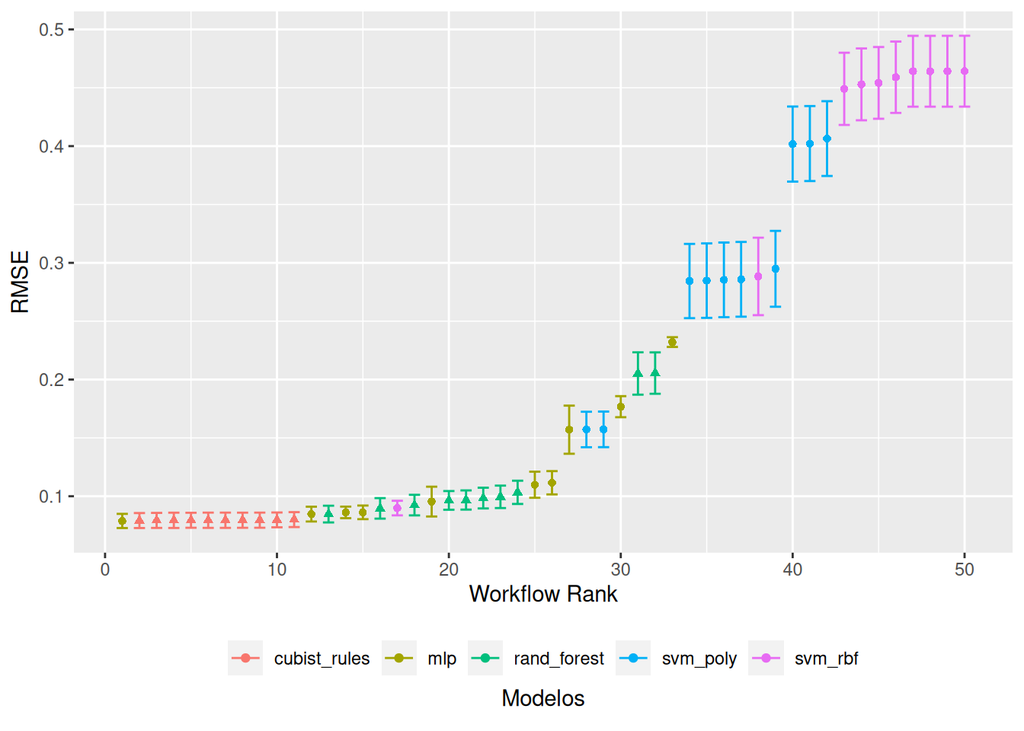

Figura 4: Modelos rankeados do melhor para o pior em função do valor da raiz quadrada do erro quadrático médio (RMSE)

```r
results |>
    autoplot(
        metric = "rmse"
    ) +
    ylab("RMSE") +
    theme(
        legend.position = "bottom"
    ) +
    theme(legend.position = "bottom") +
    guides(
        colour = guide_legend(
            title = "Modelos",
            title.position = "bottom",
            title.hjust = 0.5
        ),
        shape = "none"
    )
```

Uma métrica muito utilizada para se avaliar o desempenho de modelos é a raiz quadrada do erro quadrático médio (RMSE), que é o desvio padrão dos resíduos (valores observados - valores preditos). Nota-se na Figura 4 que todos os modelos obtiveram elevado desempenho, ($RMSE_{max} = 0,5$).

```r
# necessário finalizar os modelos com
# os melhores parâmetros
best_set_param <- results |>
    mutate(
        best_param =
            map(
                wflow_id,
                ~ results |>
                    extract_workflow(.x) |>
                    finalize_workflow(
                        results |>
                            extract_workflow_set_result(.x) |>
                            select_best(metric = "rmse")
                    )
            )
    ) |>
    select(wflow_id, best_param)
```

```r
best_set_results <- best_set_param |>
    mutate(
        .predictions =
            map(
                best_param,
                # realiza as predições nos dados de teste
                \(.x) {
                    last_fit(.x, data_split) |>
                        collect_predictions()
                }
            )
    )
```

```r
# função para plotar valores observados vs preditos de todos os modelos
plot_obs_pred_models <- function(data) {
    data |>
        unnest(.predictions) |>
        ggplot(aes(.pred, dml)) +
        geom_point(alpha = 0.3) +
        geom_abline() +
        coord_obs_pred() +
        facet_wrap(vars(wflow_id)) +
        labs(
            x = "Perda de Matéria Seca Predita (%)",
            y = "Perda de Matéria Seca Observada (%)"
        )
}
```

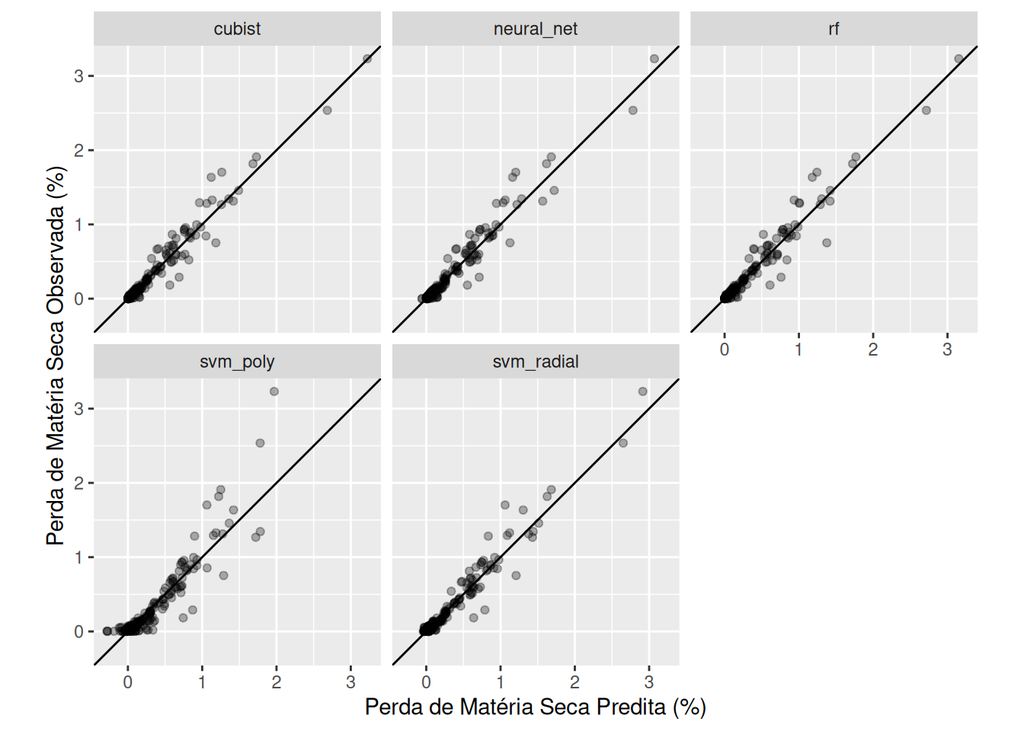

Figura 5: Valores preditos vs observados para os modelos random forest, cubist, neural network e para as vector support machines

```r
plot_obs_pred_models(best_set_results)
```

Apesar de todos os modelos apresentarem um baixo valor de RMSE, a análise dos valores preditos vs observados (Figura 5) mostra claramente que as vector support machines não são adequadas para modelar a perda de matéria seca em grãos de soja.

Diante dos resultados, surge o questionamento: qual seria o melhor modelo para estimar a perda de matéria seca de grãos de soja, em diferentes condições experimentais de temperatura e teor de umidade?

Uma das maneiras de se obter a resposta correta é observando o gráfico de resíduos vs valores preditos em busca de vieses.

```r
best_set_results_data_train <- best_set_param |>
    filter(wflow_id %in% c("rf", "cubist", "neural_net")) |>
    mutate(
        obs_pred =
            map(
                best_param,
                \(.x) {
                    fit(.x, data_train) |>
                        augment(data_train) |>
                        mutate(.resid = dml - .pred) |>
                        select(.pred, .resid)
                }
            )
    ) |>
    select(wflow_id, obs_pred) |>
    add_column(set = "Treino")
```

```r
obs_pred_set <- best_set_results_data_train |>
    bind_rows(
        best_set_results |>
            filter(wflow_id %in% c("rf", "cubist", "neural_net")) |>
            mutate(
                obs_pred = map(
                    .predictions,
                    \(.x) {
                        .x |>
                            mutate(
                                .resid = dml - .pred
                            ) |>
                            select(.resid, .pred)
                    }
                )
            ) |>
            select(wflow_id, obs_pred) |>
            add_column(set = "Teste")
    )
```

O resultado dos códigos acima é um conjunto com os valores de resíduos vs valores preditos para os bancos de dados de treino e teste.

```r
obs_pred_set
```

```
# A tibble: 6 × 3
  wflow_id   obs_pred             set
  <chr>      <list>               <chr>
1 neural_net <tibble [2,362 × 2]> Treino
2 rf         <tibble [2,362 × 2]> Treino
3 cubist     <tibble [2,362 × 2]> Treino
4 neural_net <tibble [263 × 2]>   Teste
5 rf         <tibble [263 × 2]>   Teste
6 cubist     <tibble [263 × 2]>   Teste
```

```r
# função para plotar valores de resíduo vs predito
plot_resid_pred <- function(data) {
    data |>
        unnest(obs_pred) |>
        ggplot(aes(.pred, .resid)) +
        geom_point(alpha = 0.3) +
        geom_smooth(se = F) +
        facet_wrap(
            vars(set, wflow_id)
        ) +
        labs(
            x = "Perda de Matéria Seca Predita (%)",
            y = "Resíduos"
        )
}
```

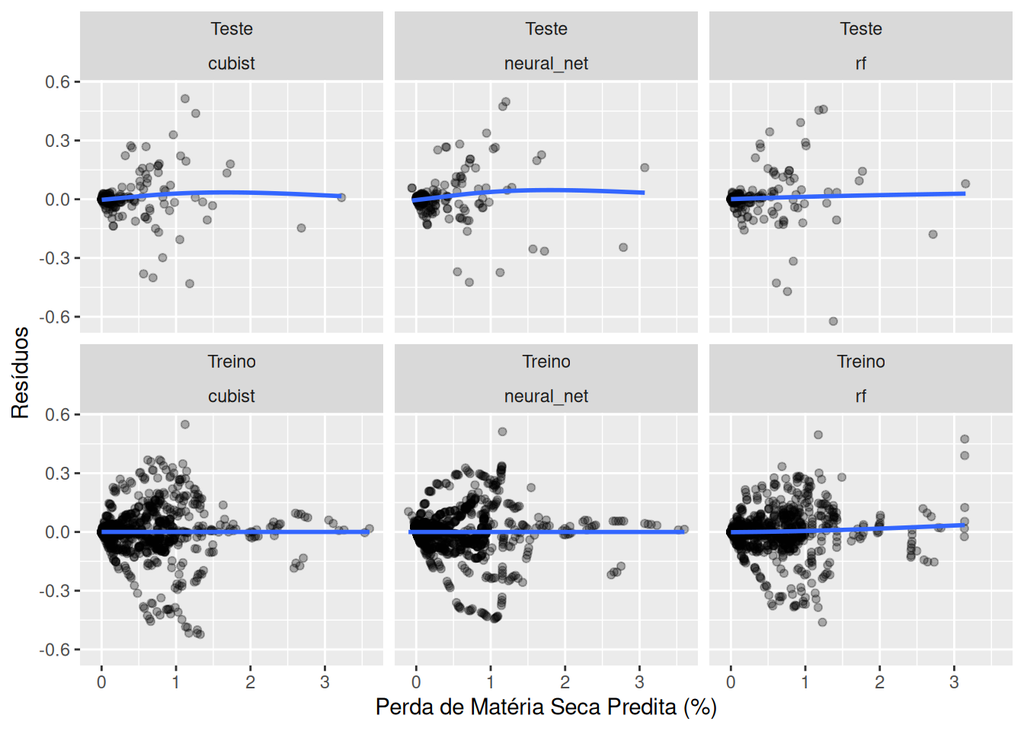

Figura 6: Valores de resíduos vs valores preditos para os bancos de dados de treino e teste

```r
plot_resid_pred(obs_pred_set)
```

# Conclusão

Analisando o gráfico de resíduos vs valores preditos (Figura 6) aparentemente não existe nenhum viés significativo para os modelos avaliados. A análise não mostra evidências claras de uma diferença significativa prática entre os modelos. É possível realizar um teste de hipóteses para detectar a diferença entre os valores de RMSE, porém, para fins práticos, qualquer um dos modelos (random forest, cubist, neural network) conseguem predizer satisfatoriamente os valores de perda de matéria seca em grãos de soja armazenados.

Tais modelos podem ser utilizados em sistemas automatizados de gestão da qualidade do grão, trazendo informações seguras sobre os riscos de perda de qualidade e quantidade do produto armazenado ao longo do tempo.

## Referências

Kuhn, Max, e Julia Silge. 2022. *Tidy Modeling with R*. " O’Reilly Media, Inc.".

Zeymer, Juliana Soares, Paulo Cesar Corrêa, Gabriel Henrique Horta de Oliveira, Richard Stephen Gates, Marcos Eduardo Viana de Araujo, e Ana Beatriz Gatsakos. 2023. "Respiration rate and dry matter loss of soybeans (Glycine max L.) obtained by a dynamic system". *International Journal of Food Science & Technology* 58 (3): 1516–27.

Zeymer, Juliana Soares, Felipe Guzzo, Marcos Eduardo Viana de Araujo, Richard Stephen Gates, Paulo Cesar Corrêa, Márcia Cristina Teixeira Ribeiro Vidigal, e Anderson Cristiano Neisse. 2021. "Machine learning algorithms to predict the dry matter loss of stored soybean grains (Glycine max L.)". *Journal of Food Process Engineering* 44 (10): e13820.